# WTI — the insulated crude

**Sample**: 2017-11-21 → 2026-04-17 · 2 169 trading days · ICE WTI M1-M12 pre-rolled settlements (`WBS 1!-ICE` … `WBS 12!-ICE`).

**What WTI is in the market**: Cushing-delivered US crude, pipeline-connected, historically isolated from global flows. Since the 2015 US export-ban repeal it sits in the Atlantic basin via USGC loadings, but it still trades with more US-domestic DNA than Brent — refinery outages in PADD 3, pipeline capacity, SPR releases all move WTI before they move Brent. That makes WTI the natural benchmark for reading *US-specific* supply stress, and the short end of Brent-WTI spread (covered in Cross-Market) for reading *basin-arb* economics.

**Sample-length caveat — up front, not in a footer.** In-sample window ends 2024-12-31; OOS is ≈16 months (≈333 trading days). All regime-frequency claims below carry wide error bars at this sample length. Direction is unambiguous; level is descriptive of the current episode, not predictive of a distribution.

**What this notebook argues**:

1. **Backwardation default, same as LSGO and Brent.** 68.2% of days print M1 > M3 — US oil storage economics favour prompt clearing except in acute contango windows.
2. **The 2026 regime is tempered on WTI.** Crisis regime ≈ 13% of OOS days, vs 17% on Brent and 31% on LSGO. US-crude insulation from Hormuz is the mechanism — disrupted AG barrels are *Brent-priced* first and WTI-priced only if/when arb economics force US exports West.
3. **The 2020-04-20 negative print** is a known artefact of May-2020 expiring contract intraday; ICE's `WBS 1!-ICE` rolls before expiry so our series doesn't capture it (M1 minimum in our data is $41.21). Event markers on the chart flag the date; readers aware of the expiring-contract context shouldn't expect to see −$37 on the rolling series.
4. **Tails are present but smaller than LSGO.** Excess kurtosis 130 sounds enormous but is driven by ~20 extreme-return days (1%); removing those leaves a near-Gaussian distribution. Compare to LSGO's 62 ex-kurtosis with 24 extreme days — WTI's tails are individually larger but less frequent.

Structured identically to the LSGO notebook: term structure → anomaly detection → event timeline/dashboard → HMM regime + forecast.

```python
import sys
sys.path.insert(0, '..')
from src import ForwardCurveAnalysis

fca = ForwardCurveAnalysis(COMMODITY='WTI').load().build()
```

```
[WTI] Loaded 2169 rows | 2017-11-21 → 2026-04-17 | 12 contracts (pre-rolled)
[WTI] Pipeline complete — 1946 rows, pre-rolled ICE series (individual rolls not recoverable)
```

```python
fca.inspect_contracts();
```

```
Contract coverage (WTI):
  WBS 1!-ICE: 1946 days | 2018-10-03 00:00:00 → 2026-04-17 00:00:00
  WBS 2!-ICE: 2169 days | 2017-11-21 00:00:00 → 2026-04-17 00:00:00
  WBS 3!-ICE: 1946 days | 2018-10-03 00:00:00 → 2026-04-17 00:00:00
  WBS 4!-ICE: 1946 days | 2018-10-03 00:00:00 → 2026-04-17 00:00:00
  WBS 5!-ICE: 1946 days | 2018-10-03 00:00:00 → 2026-04-17 00:00:00
  WBS 6!-ICE: 1946 days | 2018-10-03 00:00:00 → 2026-04-17 00:00:00
  WBS 7!-ICE: 1946 days | 2018-10-03 00:00:00 → 2026-04-17 00:00:00
  WBS 8!-ICE: 2169 days | 2017-11-21 00:00:00 → 2026-04-17 00:00:00
  WBS 9!-ICE: 1946 days | 2018-10-03 00:00:00 → 2026-04-17 00:00:00
  WBS 10!-ICE: 1946 days | 2018-10-03 00:00:00 → 2026-04-17 00:00:00
  WBS 11!-ICE: 1636 days | 2019-12-16 00:00:00 → 2026-04-17 00:00:00
  WBS 12!-ICE: 1636 days | 2019-12-16 00:00:00 → 2026-04-17 00:00:00
```

```python
fca.validate();
```

```
=== VALIDATION SUMMARY — WTI ===
Observations : 1946
Date range   : 2018-10-03 → 2026-04-17
Roll events  : 0
M1 range     : [41.21, 112.95] USD/bbl

Missing values:
  M1             :   0 ( 0.0%)
  M2             :   0 ( 0.0%)
  M3             :   0 ( 0.0%)
  M6             :   0 ( 0.0%)
  M1_M2          :   0 ( 0.0%)
  M1_M3          :   0 ( 0.0%)
  M1_M6          :   0 ( 0.0%)
  Vol_20D        :  20 ( 1.0%)
  Z_M1_M3        :   0 ( 0.0%)
  Z_M1_M6        :   0 ( 0.0%)

Extreme daily returns (>5%): 20 days
Spread ordering |M1-M3|≥|M1-M2|: 1788/1946 (91.9%)

Status: VALIDATED
```

```python
calib = fca.calibrate_thresholds(IS_END='2024-12-31')
print(f"Thresholds : {calib['thresholds']}")
print(f"IS regimes : {calib['is_regime_days']}")
print(f"OOS regimes: {calib['oos_regime_days']}")
```

```
Thresholds : {'TIGHT': 1.15, 'STRESS': 1.44, 'CRISIS': 1.61}
IS regimes : {'Normal': 1294, 'Tight': 242, 'Stress': 61, 'Crisis': 16, 'N': 1613}
OOS regimes: {'Normal': 270, 'Tight': 14, 'Stress': 5, 'Crisis': 44, 'N': 333}
```

```python
fca.summary_stats();
```

```
                                     WTI
Backwardation (M1>M3)              68.2%
M1-M3 mean (USD/bbl)                0.35
M1-M6 mean (USD/bbl)                0.73
M1-M3 max (USD/bbl)                22.17
M1-M6 max (USD/bbl)                36.70
Z-score M1-M3 peak                 76.68
Vol peak (annualised)               109%
M1-M3 skewness                     10.36
M1-M3 excess kurtosis             130.47
Corr M1-M3 vs Vol                  0.639
Corr M1-M6 vs Vol                  0.656
Days |Z|>3 (vs 0.3% expected)  34 (1.7%)
```

## 1. Term structure — price, vol, the curve

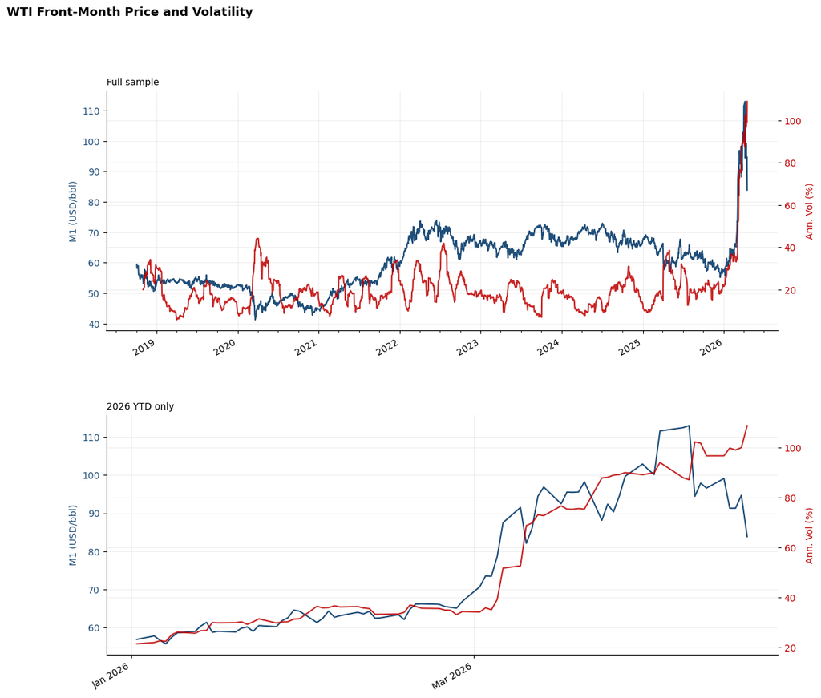

```python
fca.chart_price_vol();
```

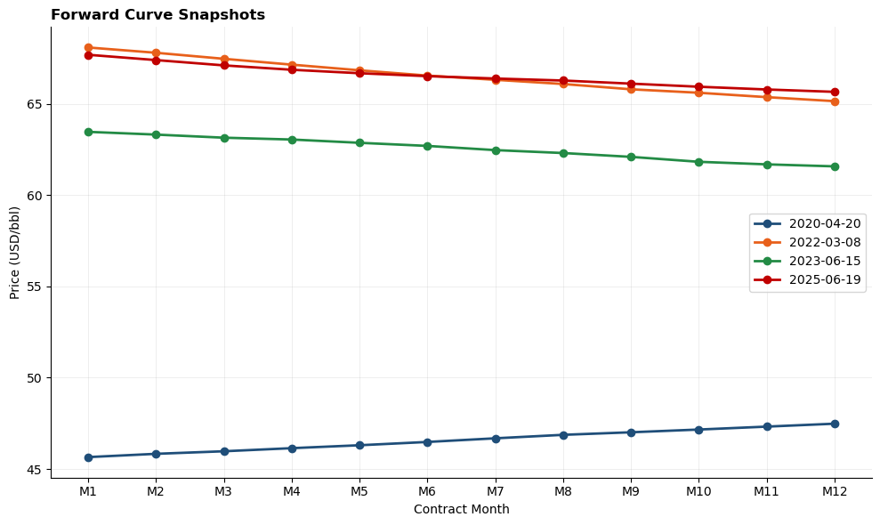

```python
fca.chart_forward_curves();
```

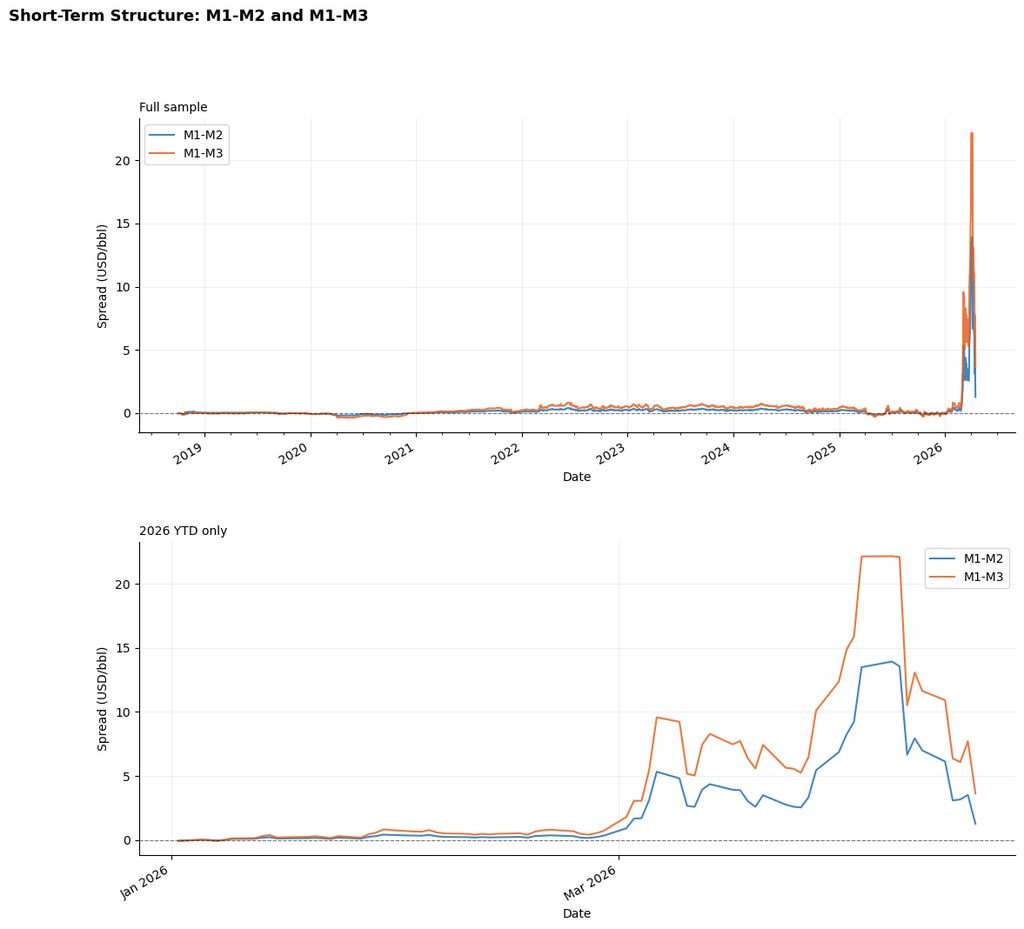

```python
fca.chart_short_structure();
```

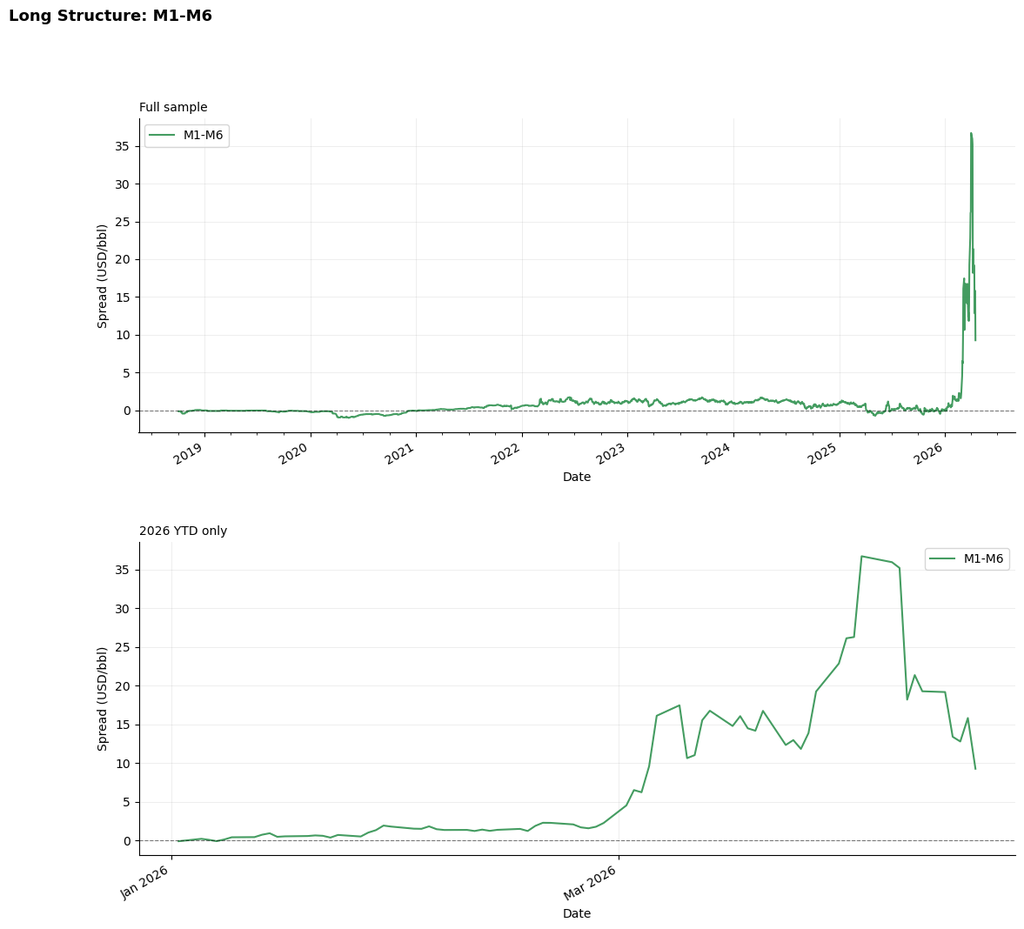

```python
fca.chart_long_structure();
```

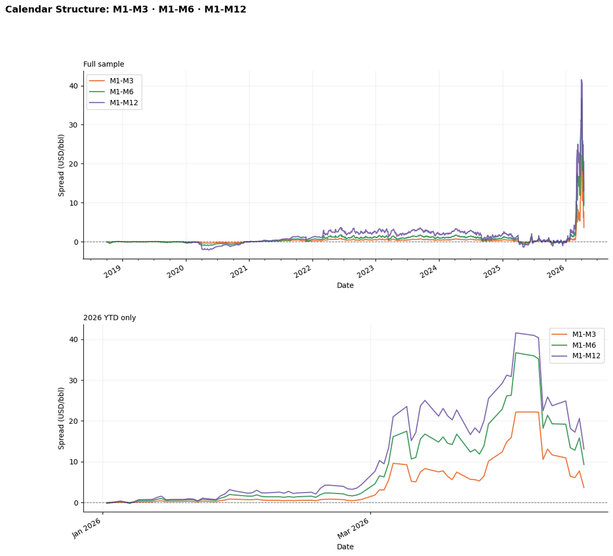

```python
fca.chart_full_strip();
```

## 2. Anomaly detection — Z-scores and the distribution

IS-anchored Z (pre-2025 mean / std as ruler). Axis capped at ±5 for readability; annotated peak values surface the off-chart magnitudes. The distribution panel separates IS (Gaussian-tailed) from OOS (fat-tailed) — WTI's excess kurtosis 130 is driven by ~20 extreme-return days; remove those and the distribution is near-Gaussian.

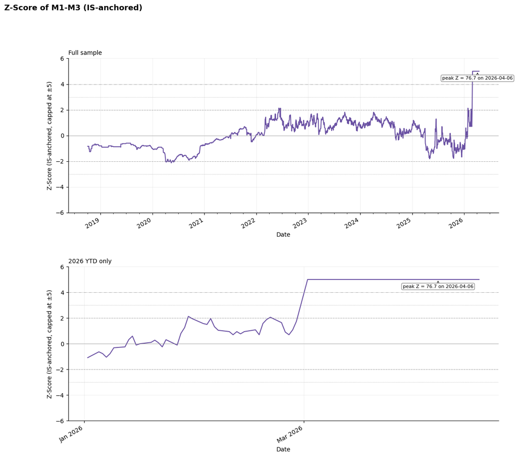

```python
fca.chart_zscore(SPREAD='M1_M3');
```

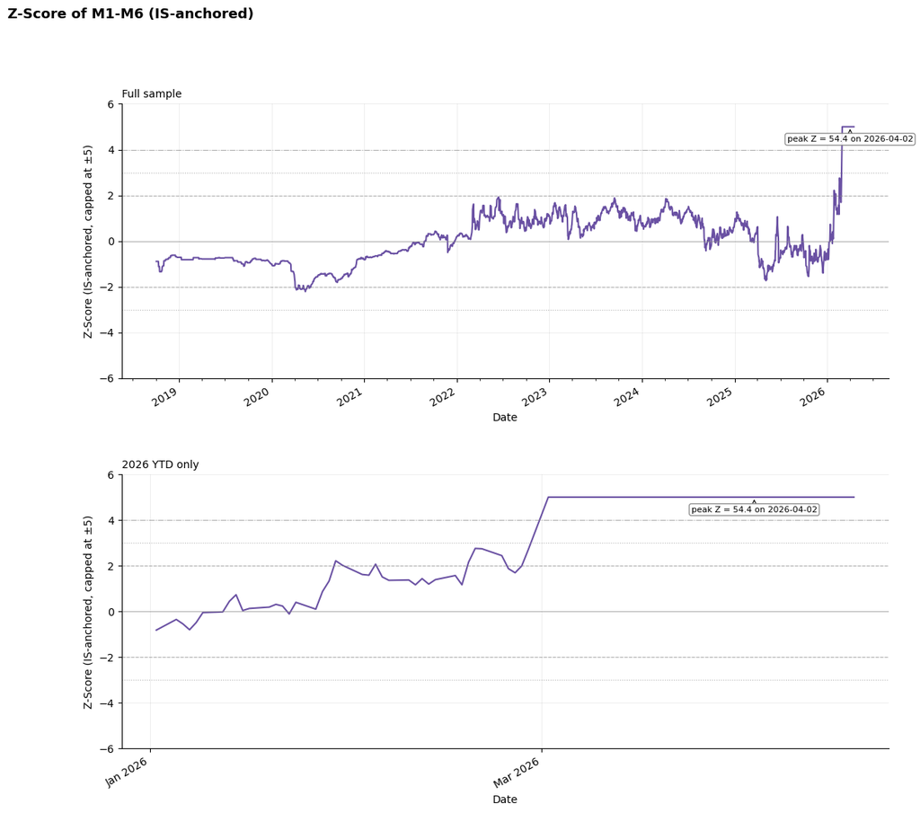

```python
fca.chart_zscore(SPREAD='M1_M6');
```

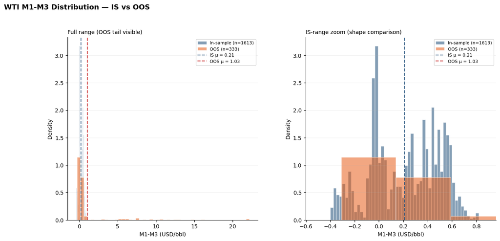

```python
fca.chart_distribution();
```

## 3. Events, dashboard, CDF regime label

Portfolio-wide event overlay on the spread series, then a 4-panel dashboard, then CDF regime classification using the pre-2025 80/95/99 percentiles on M1-M6 (Tight/Stress/Crisis thresholds 1.15 / 1.44 / 1.61 USD/bbl).

**Note on 2020-04-20**: the event line marks the date of the WTI negative settlement (expiring May-2020 contract, intraday −$37). ICE's rolling front-month `WBS 1!-ICE` rolls before expiry, so the rolling series does *not* show the negative print — our M1 minimum is $41.21. The event marker is a date, not a price point; readers aware of the expiring-contract context shouldn't expect to see −$37 on the rolling series.

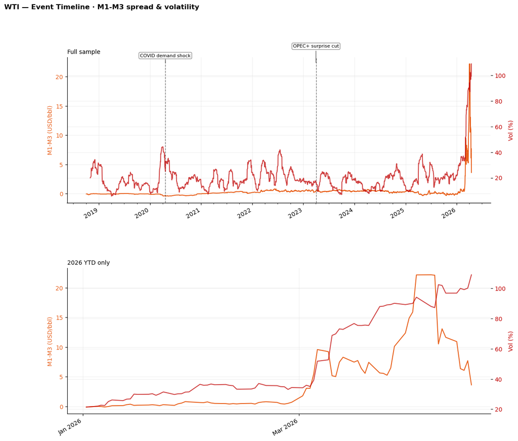

```python
fca.chart_event_timeline();
```

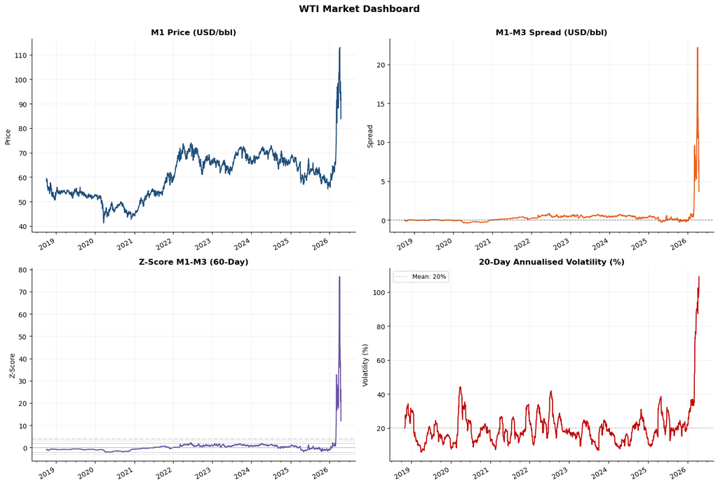

```python
fca.chart_dashboard();
```

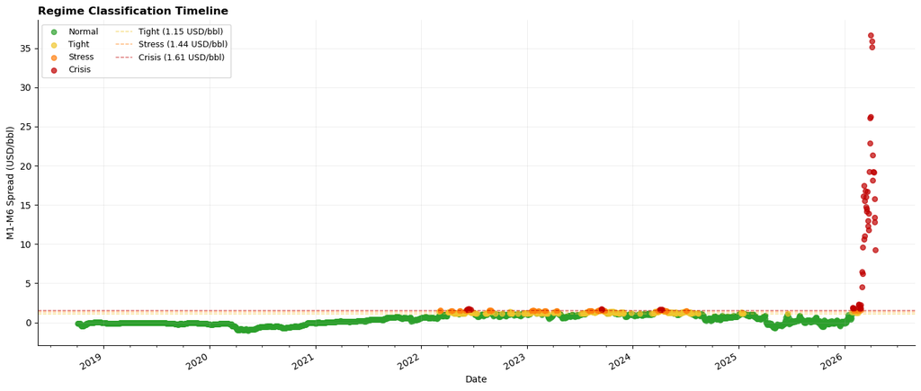

```python
fca.chart_regime();
```

## 4. HMM probabilistic regime + next-day forecast

Same methodology as LSGO/Brent. HMM probabilities complement the CDF hard labels; the transition matrix gives next-day regime probabilities. In the current OOS window the stay-in-state-1 probability is ≈1, so the forecast horizon trivially extrapolates — informative only because it reveals the regime is *persistent*, not transient.

```
HMM means (by state): [ 0.44562533 16.64442367]
HMM std   (by state): [0.6557333  7.84476475]
Transition matrix:
[[9.99476848e-01 5.23152140e-04]
 [1.58580231e-15 1.00000000e+00]]
IS  P(crisis)>0.5 days: 0/1613 (0.0%)
OOS P(crisis)>0.5 days: 34/333 (10.2%)
```

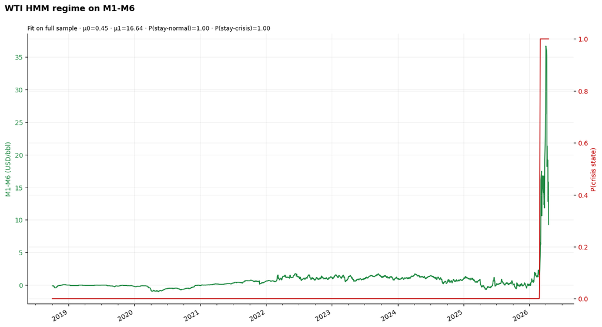

```python
fca.chart_hmm_regime(SPREAD='M1_M6', N_STATES=2);
```

### Forward-looking forecast

From today's HMM state probabilities, iterate the transition matrix 5 business days forward. Non-zero `P(crisis)` tomorrow means the regime is still active — the transition matrix's stay-crisis probability is close to 1 during the 2026-Q2 OOS window.

```python
fca.forecast_next_day_regime(HORIZON=5);
```

```
As of 2026-04-17:
  today  P(state0)=0.000 · P(state1)=1.000
  +1d    P(state0)=0.000 · P(state1)=1.000
  +2d    P(state0)=0.000 · P(state1)=1.000
  +3d    P(state0)=0.000 · P(state1)=1.000
  +4d    P(state0)=0.000 · P(state1)=1.000
  +5d    P(state0)=0.000 · P(state1)=1.000
```

## Trader takeaways

- **WTI is the insulated crude.** Same directional behaviour as Brent but ~50% of the magnitude during geopolitical events. When Hormuz is the shock (2026), trade Brent; when US-inland is the shock (Cushing congestion, PADD3 refinery outages), trade WTI.
- **Brent-WTI basin spread is the cleanest US-vs-world read.** See ../Cross_Market_Analysis/ — at $7-8/bbl the arb opens for USGC crude to Europe, mechanically compressing the gap.
- **The 2020 negative print is a known artefact** of the expiring May contract, not captured in our rolling M1 series. Cite the date, don't quote the −$37 on charts that only show the rolling series.
- **Regime thresholds** (80/95/99 pct of pre-2025 M1-M6): Tight 1.15 · Stress 1.44 · Crisis 1.61 USD/bbl. OOS Crisis 13% — the mildest of the three commodities.
- **Tail frequency is low**, magnitudes high. Use option structures for downside protection in crisis windows; linear hedges under-price the gap risk.